# Assignment_05

#### 20145271 Geum Kang Hyeon

## K-means algorithm on color image

Let $f(x)$ be a color image and $x$ be the index of image in the domain. The values of image $f(x)$ consist of [red, green, blue] intensity.

Apply K-means algorithm to image $f(x)$ based on its color value with given number of clusters $K$ and visualize the progress of optimization and results of the algorithm for each selected number of clusters $K$.

1. Select any color image that consists of distinctive regions with different colors.
2. Apply K-means algorithm to the given image with at least 4 different choice of $K$.
3. For each $K$, plot the energy curve and the result image.

[Energy]

$$\frac{1}{n} \sum_{x \in \Omega} \| f(x) - m_c \|^2,$$

where $\Omega$ denotes the image domain and the number of pixels $| \Omega |$ is $n$, and $m_c$ denotes the centroid for cluster $c$ that is the cluster label of $f(x)$.

[Output Image]

$g(x) = m_c$ where $label(x) = c$

Each pixel of the output image $g(x)$ should be its centroid $m_c$ where $c$ is the cluster label of $g(x)$.

### Code Explaination

The process consists of 7 main stages.

```python
import matplotlib.pyplot as plt
import numpy as np
import math, random
from PIL import Image
np.seterr(divide='ignore', invalid='ignore')

def L2_distance(source, target):
    sum = sum_of_square(source, target)
    return math.sqrt(sum)

def sum_of_square(source, target):
    sum =  0
    sum += (source[:] - target[:]) ** 2
    return np.sum(sum)


def plot(k, random_label, centroid_vector, img, energy_data):
    for idx in range(k):

        pixelMap = img.load()

        temp_img = Image.new(img.mode, img.size)
        pixelsNew = temp_img.load()

        for i in range(temp_img.size[0]):
            for j in range(temp_img.size[1]):
                if random_label[j*temp_img.size[0] + i] == idx:
                    pixelsNew[i,j] = (int(centroid_vector[idx][0]), int(centroid_vector[idx][1]), int(centroid_vector[idx][2]))
                else:
                    pixelsNew[i,j] = (255,255,255)

        print("Image of Cluster ", idx+1)
        display(temp_img)

    plt.title("Energy")
    plt.plot(energy_data)
    plt.show()


def clustering(filename, k):
    img = Image.open(filename, 'r')

    width, height = img.size
    img = img.convert("RGB")
    pixel_values = list(img.getdata())

    num_pixel = width * height

    print("Origin Image")
    display(img)

    random_label = np.empty(num_pixel, dtype=int)
    backup_label = np.empty(num_pixel, dtype=int)

    for idx in range(num_pixel):
        random_label[idx] = np.random.randint(0,k,1)


    energy = 0
    energy_data = []

    for loop in range(100):

        new_energy = 0

        centroid_vector = np.zeros((k, 3), dtype=float)
        centroid_vector_count = np.zeros(k, dtype=int)
        countIdx = np.zeros(k, dtype=int)

        # centroid image
        for i in range(num_pixel):
            centroid_vector[int(random_label[i])] += pixel_values[i]
            centroid_vector_count[int(random_label[i])] += 1

        for i in range(k):
            centroid_vector[i,:] /= centroid_vector_count[i]

        zero_check = False
        for i in range(k):
            if(centroid_vector_count[i] == 0):
                random_label = np.empty(num_pixel, dtype=int)
                for idx in range(num_pixel):
                    random_label[idx] = np.random.randint(0,k,1)
                zero_check = True
                break

        if(zero_check == False):
             # compare image
            for i in range(num_pixel):
                temp = pixel_values[i]
                distance = np.zeros(k, dtype=float)

                for index in range(k):
                    distance[index] = L2_distance(temp, centroid_vector[index])

                label = np.argmin(distance)
                new_energy += sum_of_square(temp, centroid_vector[label])

                backup_label[i] = label


            random_label = backup_label

            # calculate energy
            new_energy /= num_pixel
            energy_data.append(new_energy)

            if energy == 0:
                energy = new_energy
            elif abs(new_energy - energy) < 1:
                plot(k, random_label, centroid_vector, img, energy_data)
                break
            else:
                energy = new_energy
```

1) k is 3

```
Origin Image
```

```
Image of Cluster  1
```

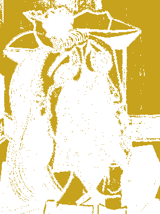

```
Image of Cluster  2
```

[figure not shown]

```
Image of Cluster  3
```

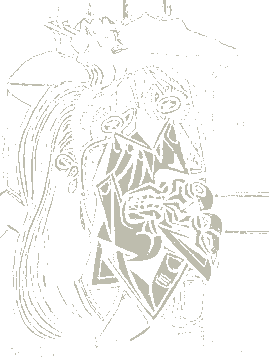

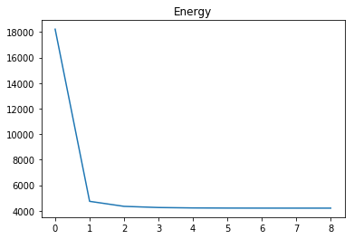

```python
clustering('picasso.jpg', 3)
```

2) k is 5

```
Origin Image
```

```
Image of Cluster  1
```

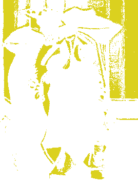

```
Image of Cluster  2
```

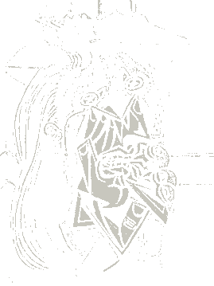

```
Image of Cluster  3
```

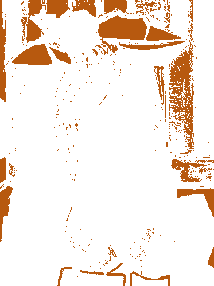

```
Image of Cluster  4
```

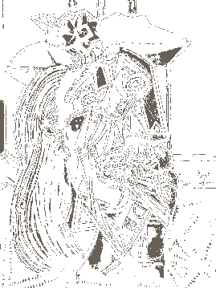

```
Image of Cluster  5
```

[figure not shown]

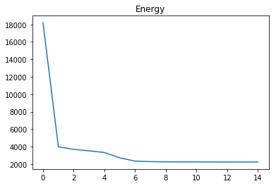

```python
clustering('picasso.jpg', 5)
```

3) k is 7

```
Origin Image
```

```
Image of Cluster  1
```

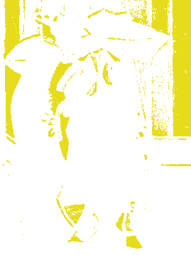

```
Image of Cluster  2
```

[figure not shown]

```
Image of Cluster  3
```

[figure not shown]

```
Image of Cluster  4
```

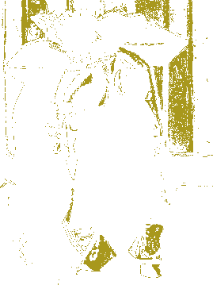

```
Image of Cluster  5
```

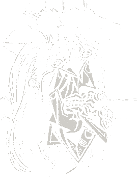

```
Image of Cluster  6
```

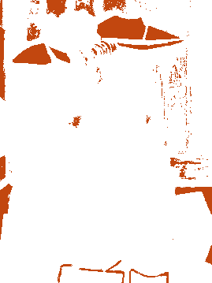

```
Image of Cluster  7
```

[figure not shown]

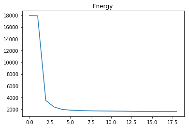

```python
clustering('picasso.jpg', 7)
```

4) k is 9

```
Origin Image
```

```
Image of Cluster  1
```

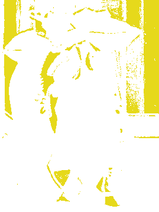

```
Image of Cluster  2
```

[figure not shown]

```
Image of Cluster  3
```

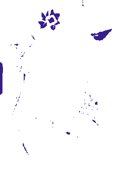

```
Image of Cluster  4
```

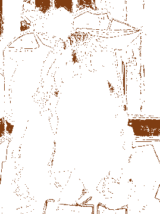

```
Image of Cluster  5
```

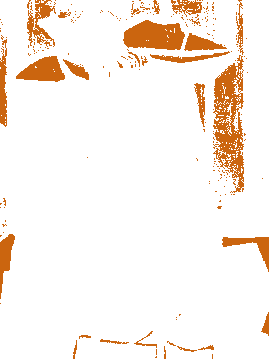

```
Image of Cluster  6
```

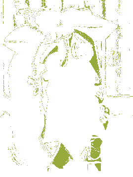

```
Image of Cluster  7
```

[figure not shown]

```
Image of Cluster  8
```

[figure not shown]

```
Image of Cluster  9
```

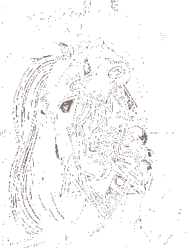

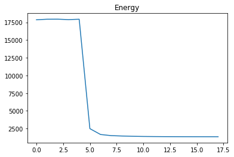

```python
clustering('picasso.jpg', 9)
```